# 広島県 (議員定数：7 → 6)

アルゴリズムによる衆議院小選挙区の区割り改訂案

**広島県**

人口： 2,713,163 人（2020年）

|  | 現行 | アルゴリズムの提案 市区町村の分割無し | アルゴリズムの提案 最大市区町村の分割可 |
| --- | --- | --- | --- |
| **1票の格差** |  |  |  |
| 県内較差 | 1.724 | 1.154 | 1.154 |
| 改善率 | - | 78.7% | 78.7% |
| **選挙区の状況** |  |  |  |
| 選挙区数 | 7 | 6 | 6 |
| 市区町村の分割 | 4<sup>a</sup> | 0 | 1<sup>b</sup> |
| 郡の分割 | 0 | 0 | 0 |
| 広域連携地域の分割 | 3<sup>c</sup> | 3<sup>c</sup> | 3<sup>c</sup> |

<sup>*a*</sup> 江田島市、尾道市、東広島市、三原市 <sup>*b*</sup> 福山市 <sup>*c*</sup> 広島広域都市圏、備後圏域、広島中央地域連携中枢都市圏

# 現行の区割り

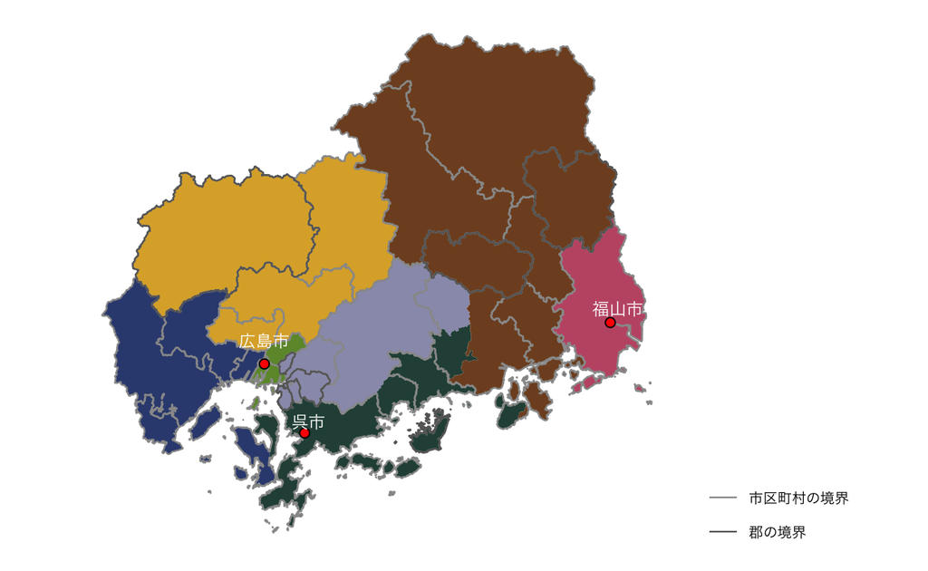

# アルゴリズムの提案

アルゴリズムが提案した25,000案のうち、有効な案の中で、一票の格差が最小のもの

### 市区町村を分割しない区割り案

一票の格差 : 1.154

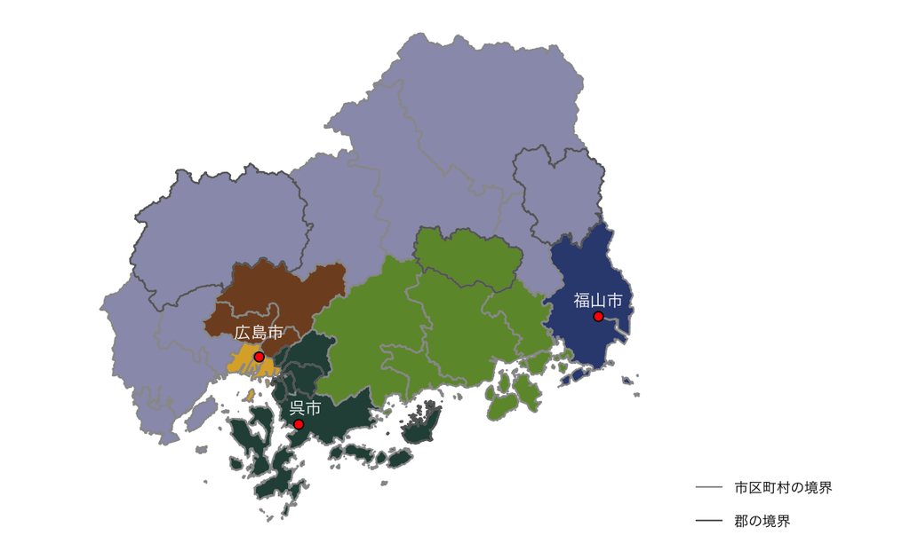

### 最大市区町村の分割を許容する区割り案

人口が最大の市区町村 : 福山市

一票の格差 : 1.154

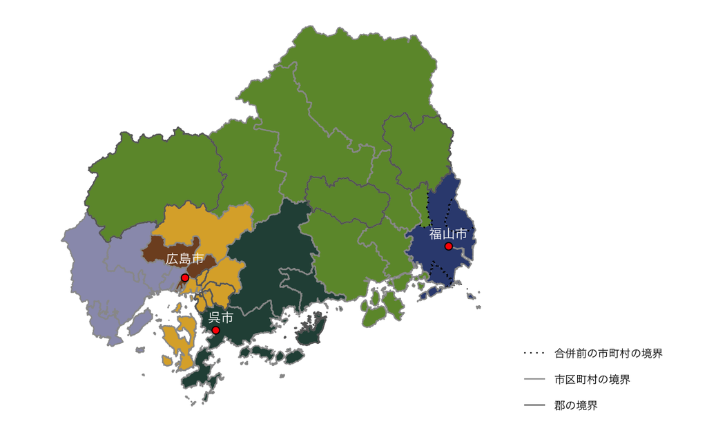

# 共起分析

- アルゴリズム設定
  - 市区町村の分割無し
  - 飛び地を含む案を棄却
  - 一票の格差が下位10％の案を抽出
- 読み取り方  
  地図上の市区町村の色が
  - 同じ → 同じ選挙区に属する傾向が強い
  - 同じ かつ 濃い → 隣接する市区町村と同じ選挙区に属する傾向が強い

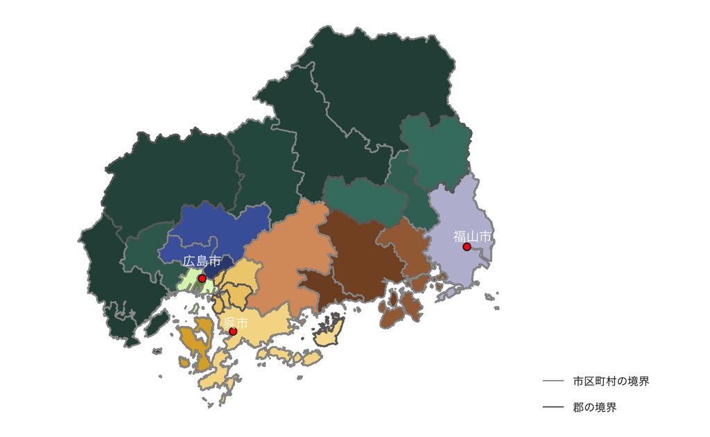

# アルゴリズム設定

- 各選挙区の人口 : (県内の総人口 / 選挙区数) ±10%
- アルゴリズムが導出する案の総数 : 25,000
- 有効な区割り案（飛び地を生じさせない）の数 :
  - 市区町村の分割無し : 4,079
  - 人口最大の市区町村の分割を許容 : 4,430
- 有効な案から一票の格差が最小の区割り案を選定

### 県特有の設定

飛び地を防ぐため、以下の案は棄却:

- 安芸郡と広島市安芸区が異なる選挙区に属する案
- 竹原市及び呉市が、東広島市と異なる選挙区に属する案